# Recalling Words

#### Background

Many teachers and other educators are interested in understanding how to best deliver new content to students. In general, they have two choices of how to do this.

1. The Meshed Approach
   - Deliver new content while simultaneously reviewing previously understood content.
2. The Before Approach
   - Deliver new content after fully reviewing previously understood content.

A study was performed to determine whether the *Meshed* or *Before* approaches to delivering content had any positive benefits on memory recall.

##### The Experiment (click to view)

## Question and Hypotheses

I chose to look at the equality of the medians of correctly recalled words of two possibly different distributions in two seperate Wilcoxon Rank Sum Tests.

The first test was run to check the equality of the medians of two possibly different distributions of the correct number of words recalled between the Before approach and the Standard Free Recall. The second test was the same test, but with the Meshed approach compared to the Standard Free Recall approach.

The null and alternative hypotheses for each of these tests will be:
$$H_O: \text{The distributions are stochastically equal}$$
$$H_a: \text{One distribution is stochastically greater than the other}$$
The significance level for each of these tests will be set at:

$$\alpha =0.05$$
Due to two tests being run, the total alpha, or probability of at least one type I error will be:
$$\alpha = 0.10$$
—-

## Data

In order to properly conduct this study, I created two seperate datasets from the original Friendly dataset. The first dataset contains 20 individuals, 10 from the before group and 10 from the SFR group. The second dataset also contains 20 observations; 10 from the Meshed group and 10 from the SFR group. It is important to know that each group of 10 was the entirety of observations from each respective group, and that the 2 SFR groups in each of the filtered datasets are in actuality the exact same observations and serve as a control group. The original Friendly dataset containing all 30 observations was still used in the boxplot and the data summary table in order to be better organized. Though 10 is a small number of observations, since we are running a Wilcoxon Rank Sum test, the small sample size is satisfactory for the purposes of this study.

## Analysis

The boxplots below suggest that both the Meshed and Before approaches have higher word recall outcomes than does the SFR approach, with the Before approach being slightly higher than the Meshed.

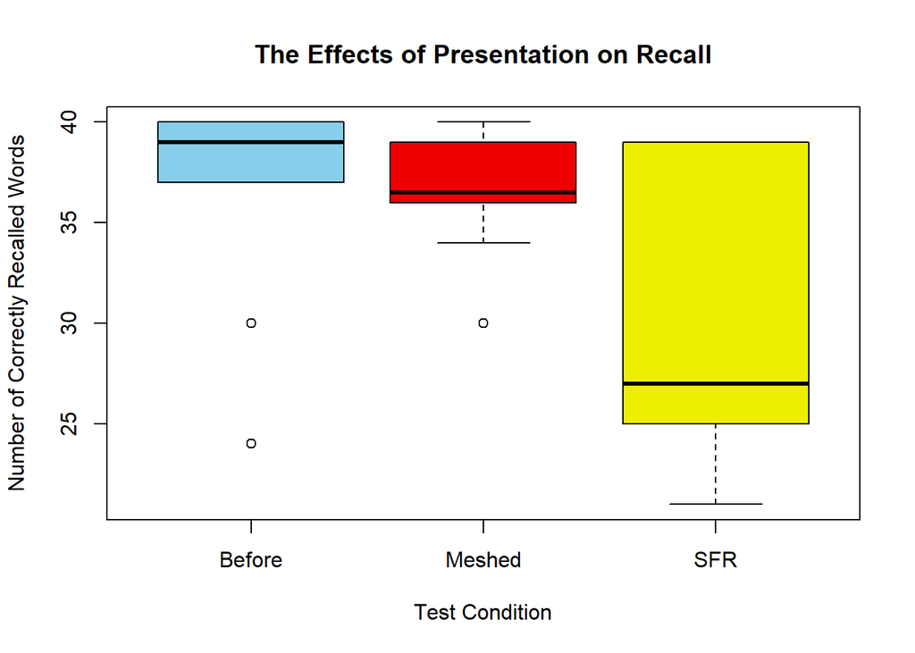

```r
boxplot(correct ~ condition, data=Friendly, col=c("skyblue", "red2", "yellow2"), ylab="Number of Correctly Recalled Words", xlab="Test Condition", main="The Effects of Presentation on Recall")
```

Below is a Numerical Summary of the data contained in the above boxplots for each group:

```r
Friendly %>%
  group_by(condition) %>%
  summarise(min= min(correct), median = median(correct), mean = mean(correct), max = max(correct), sd = sd(correct),'Number of observations' = n()) %>%
  pander(caption="Summary of Approach Effectiveness")
```

Summary of Approach Effectiveness

| condition | min | median | mean | max | sd | Number of observations |
| --- | --- | --- | --- | --- | --- | --- |
| Before | 24 | 39 | 36.6 | 40 | 5.337 | 10 |
| Meshed | 30 | 36.5 | 36.6 | 40 | 3.026 | 10 |
| SFR | 21 | 27 | 30.3 | 39 | 7.334 | 10 |

In order to determine if these results are signifcant, two seperate Wilcoxon Rank Sum tests were run, as previsouly mentioned. The first test results are for the Before dataset, and the second results correspond to the Meshed dataset. It is also important to note that an exact p-value cannot be computed for either test, due to the fact that they both contain at least one tie.

```r
wilcox.test(correct ~ condition, data=FriendlyB4, alternative = "greater") %>% pander()
```

Wilcoxon rank sum test with continuity correction: `correct` by `condition`

| Test statistic | P value | Alternative hypothesis |
| --- | --- | --- |
| 76.5 | 0.02278 * | greater |

```r
wilcox.test(correct ~ condition, data=FriendlyMeshed, alternative = "greater") %>% pander()
```

Wilcoxon rank sum test with continuity correction: `correct` by `condition`

| Test statistic | P value | Alternative hypothesis |
| --- | --- | --- |
| 72 | 0.05075 | greater |

## Conclusion

Based on the results of the first test, which is comparing the distributions of the Before observations to the distribution of the SFR observations, we are able to reject our null hypothesis because $(p = 0.02278 < \alpha)$. This means we have sufficient evidence to claim that the claim that one distribution is stochastically greater than the other. The difference observed in the boxplot and numerical summary is now supported by the p-value and is thus deemed as significant, meaning that the median of the Before group is stochastically greater than the median of the SFR observation group.

We conclude that the Before approach does have a significant positive effect on the number of correct words recalled compared to the SFR approach, and that the Meshed approach does not have a significant positive effect on the amount of correct words recalled. Based on these results and conclusions, I would encourage more schools and education systems to incorporate the Before teaching approach into their curriculums.